# P7-simona

2022-11-05

```r
library(MASS)
library(splines)
library(ISLR)
library(tidyverse)
set.seed(45)
```

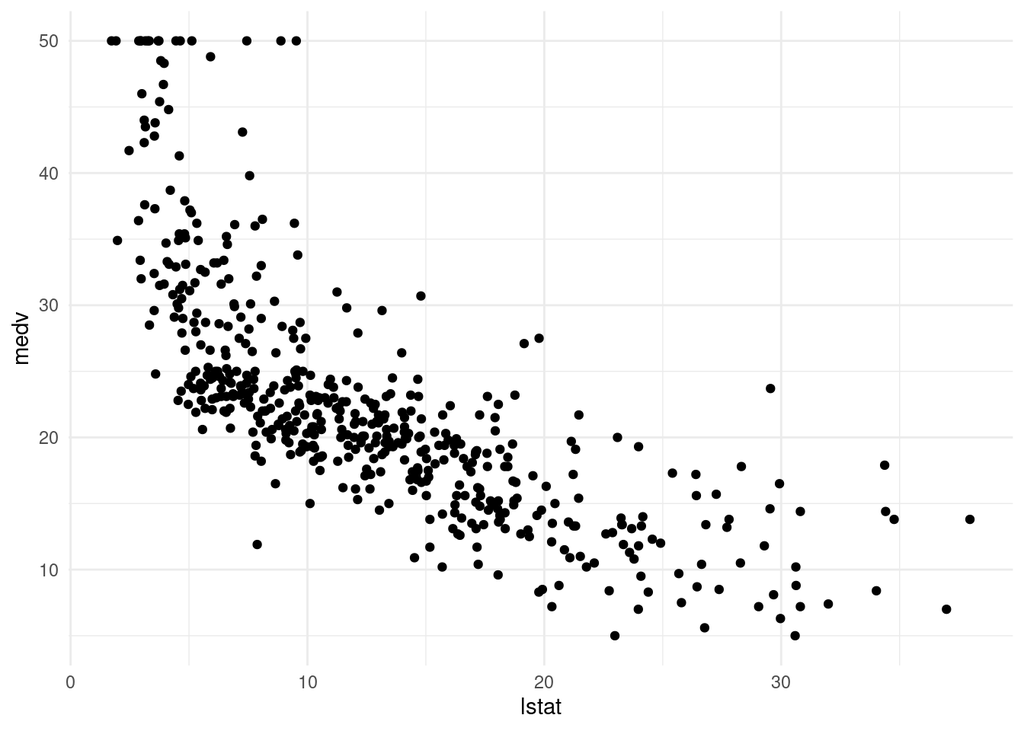

```r
Boston %>%
  ggplot(aes(x = lstat, y = medv)) +
  geom_point() +
  theme_minimal()
```

1. Create a function called pred_plot() that takes as input an lm object, which outputs the above plot but with a prediction line generated from the model object using the predict() method.

```r
pred_plot <- function(model) {

  pred <- predict(model)
  new_df <- data.frame(actual = Boston$lstat, predicted =  pred)

  Boston %>%
    ggplot(aes(x = lstat, y = medv)) +
    geom_point() +
    geom_line(color = "red", data = new_df, aes(x = actual, y = predicted)) +
    theme_minimal()
}
```

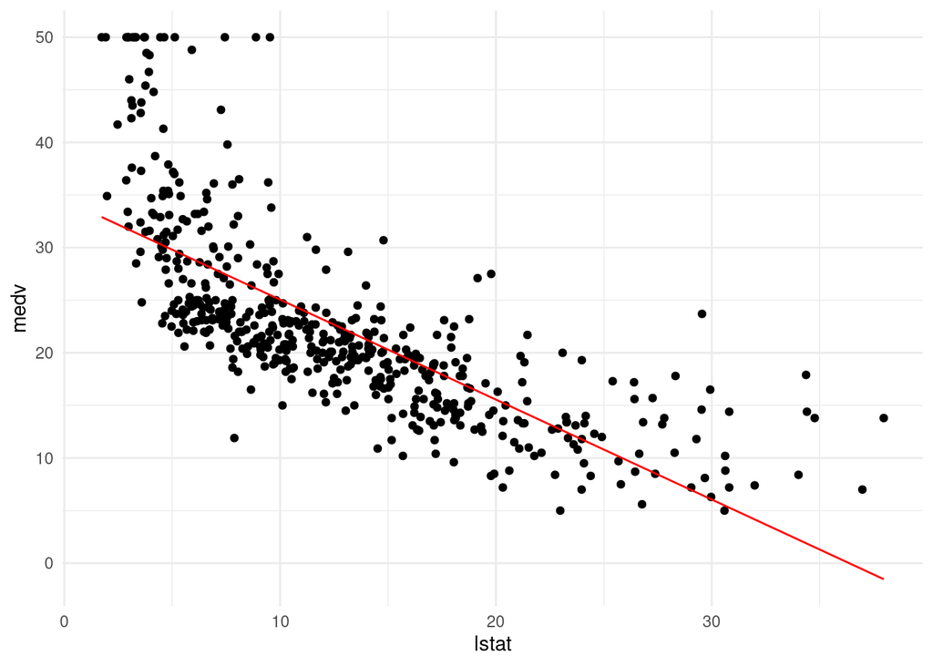

```r
lm_Boston = lm(medv ~ lstat, data = Boston)
pred_plot(lm_Boston)
```

Topmost data is not fitted.

3. Create another linear model pn3_mod, where you add the second and third-degree polynomial terms I(lstat^2) and I(lstat^3) to the formula. Create a pred_plot() with this model.

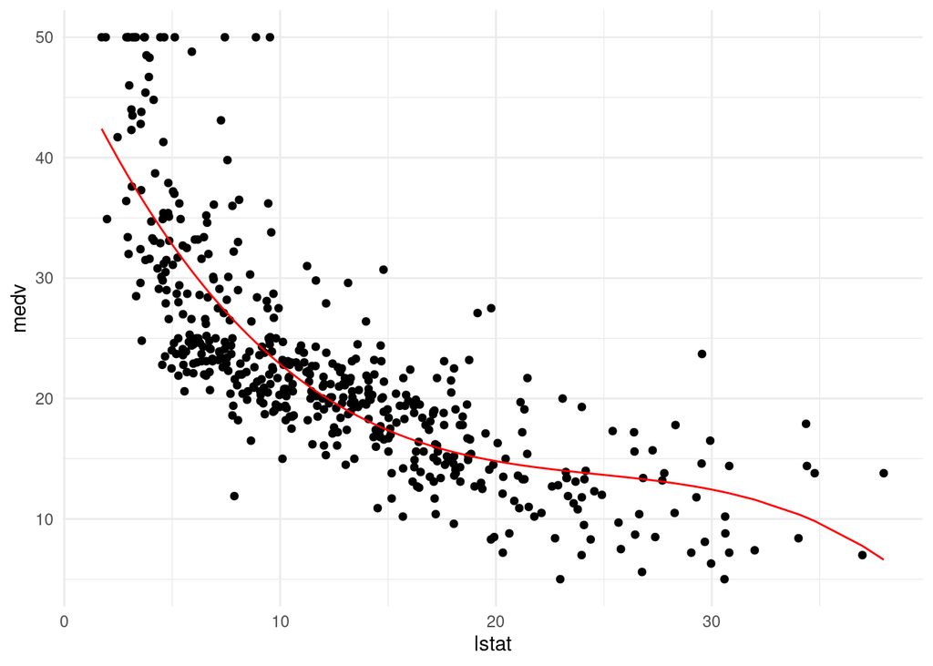

```r
pn3_mod <- lm(medv ~ lstat + I(lstat^2) + I(lstat^3), data = Boston)

pred_plot(pn3_mod)
```

4. The function poly() can automatically generate a matrix which contains columns with polynomial basis function outputs.

Play around with the poly() function. What output does it generate with the arguments degree = 3 and raw = TRUE?

```r
poly(seq(1:3), degree = 3, raw= TRUE)
```

```
##      1 2  3
## [1,] 1 1  1
## [2,] 2 4  8
## [3,] 3 9 27
## attr(,"degree")
## [1] 1 2 3
## attr(,"class")
## [1] "poly"   "matrix"
```

5. Use the poly() function directly in the model formula to create a 3rd-degree polynomial regression predicting medv using lstat. Compare the prediction plot to the previous prediction plot you made. What happens if you change the poly() function to raw = FALSE?

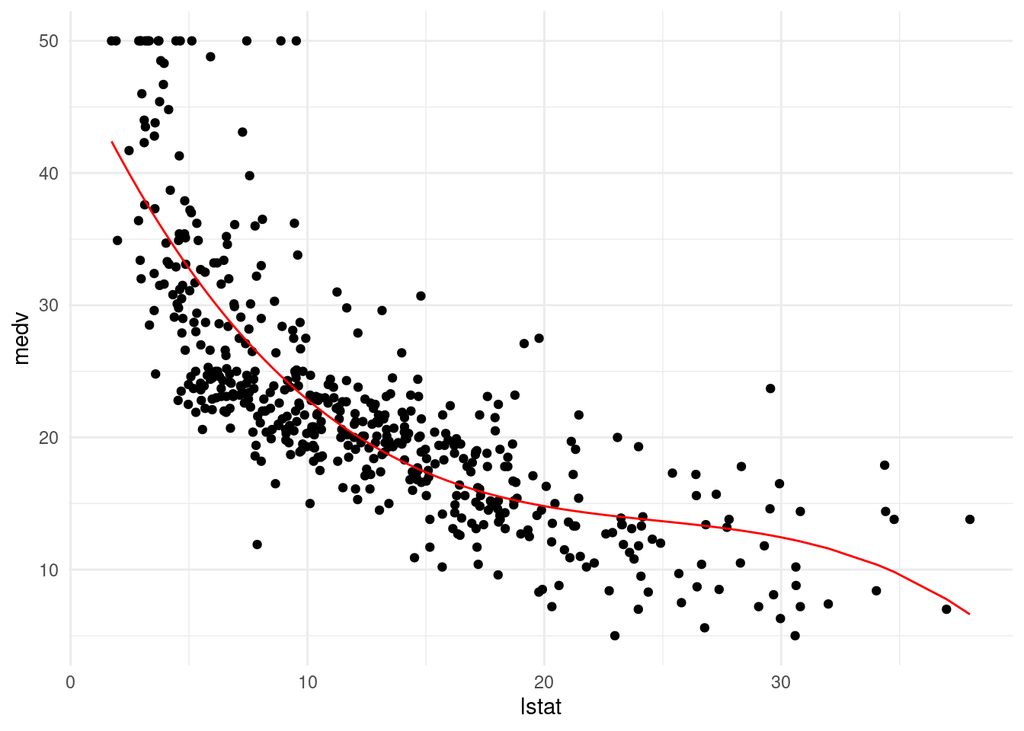

```r
pol_2 <- lm(medv ~ poly(lstat, 3, raw = TRUE), data = Boston)
pred_plot(pol_2)
```

This plot is exactly the same as previous.

6. Create a model called pw2_mod with one predictor: I(lstat <= median(lstat)). Create a pred_plot with this model. Use the coefficients in coef(pw2_mod) to find out what the predicted value for a low-lstat neighbourhood is.

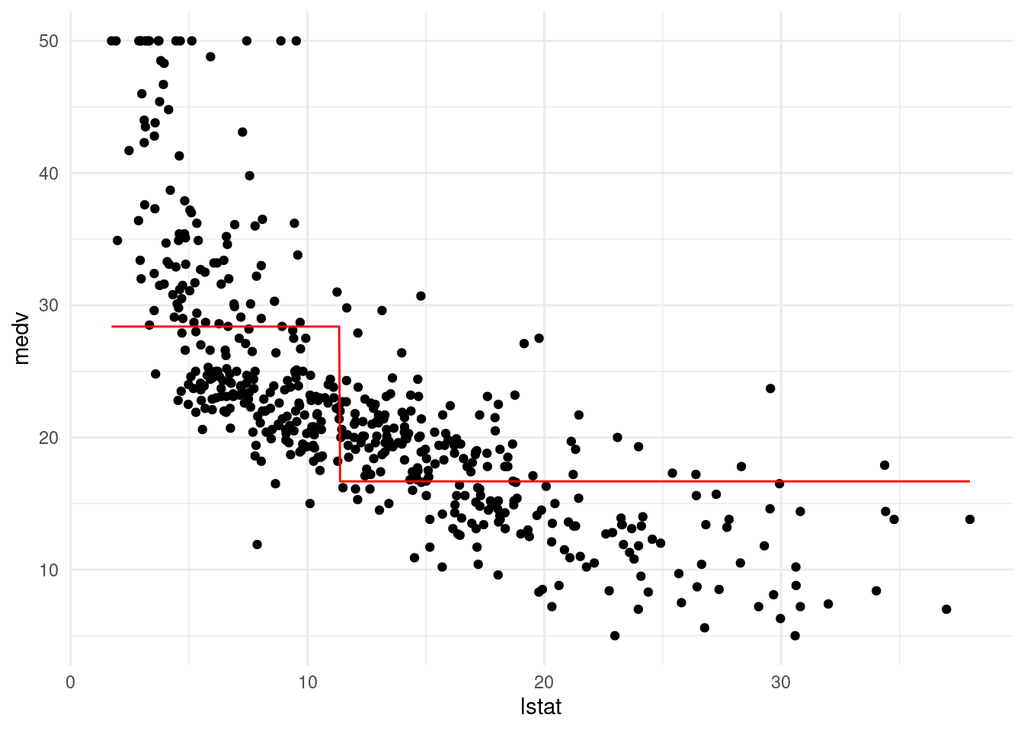

```r
pw2_mod <- lm(medv ~ I(lstat <= median(lstat)), data = Boston)

pred_plot(pw2_mod)
```

```r
coef(pw2_mod)
```

```
##                   (Intercept) I(lstat <= median(lstat))TRUE
##                      16.67747                      11.71067
```

Predicted value of a low lstat is 11.7 + 16.6 = 28.3

7. Use the cut() function in the formula to generate a piecewise regression model called pw5_mod that contains 5 equally spaced sections. Again, plot the result using pred_plot.

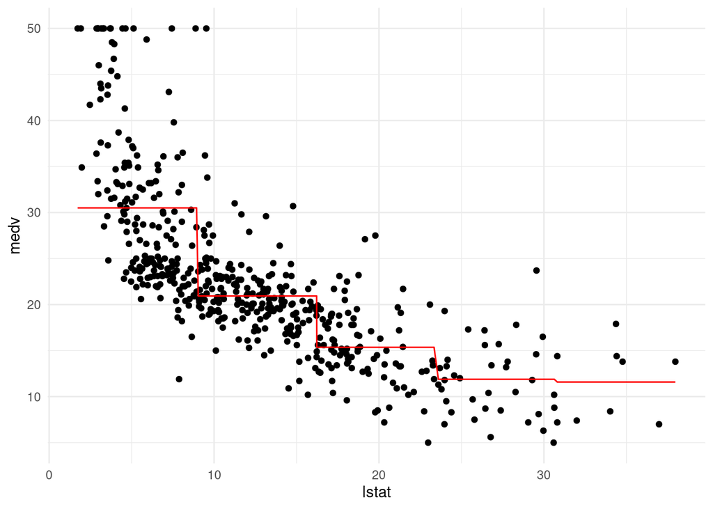

```r
pw5_mod <- lm(medv ~ I(cut(lstat, breaks = 5)), data = Boston)

pred_plot(pw5_mod)
```

```r
table(cut(Boston$lstat, 5))
```

```
##
## (1.69,8.98] (8.98,16.2] (16.2,23.5] (23.5,30.7]   (30.7,38]
##         183         183          94          37           9
```

8. Optional: Create a piecewise regression model pwq_mod where the sections are not equally spaced, but have equal amounts of training data. Hint: use the quantile() function.
9. This function does not have comments. Copy - paste the function and add comments to each line. To figure out what each line does, you can first create “fake” vec and knots variables, for example vec <- 1:20 and knots <- 2 and try out the lines separately.

```r
piecewise_cubic_basis <- function(vec, knots = 1) {
#if there are no knots raise to power values from a vector
  if (knots == 0) return(poly(vec, degree = 3, raw = TRUE))

  #cut the vector
  cut_vec <- cut(vec, breaks = knots + 1)

  #transform the vector into a matrix
  out <- matrix(nrow = length(vec), ncol = 0)

  #for every interval in cut_vect
  for (lvl in levels(cut_vec)) {

   #the vector is cloned into tmp variable
    tmp <- vec

    #values of vector that dont belong to the interval = 0
    tmp[cut_vec != lvl] <- 0

    #attach to the matrix containing the values of the vector columns wit the values ^1/2/3
    out <- cbind(out, poly(tmp, degree = 3, raw = TRUE))

  }
  #get the picewise polynomial matrix
  out
}
```

10. Create piecewise cubic models with 1, 2, and 3 knots (pc1_mod - pc3_mod) using this piecewise cubic basis function. Compare them using the pred_plot() function.

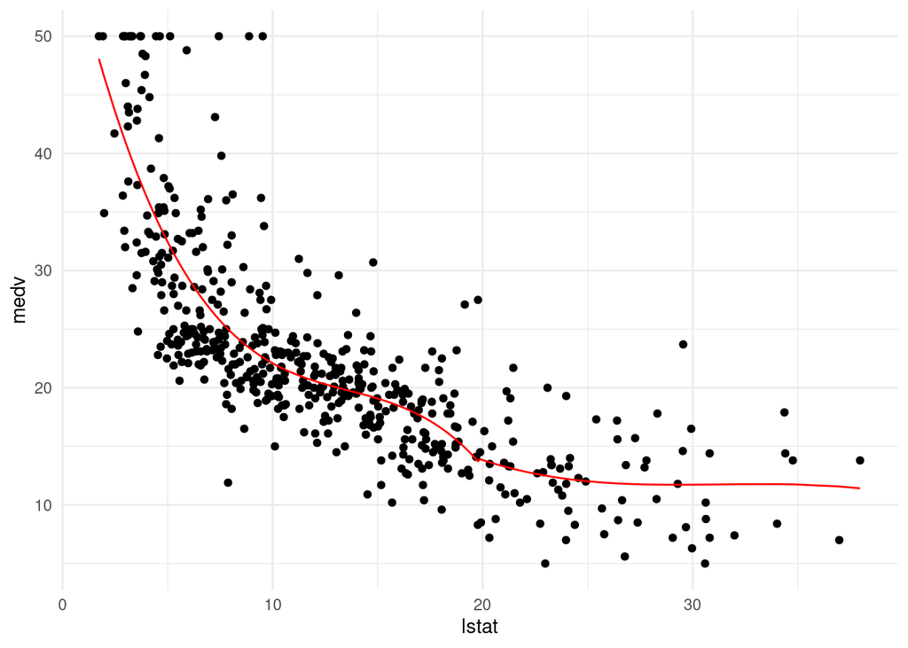

```r
pc1_mod <- lm(medv ~ piecewise_cubic_basis(lstat, 1), data = Boston)
pc2_mod <- lm(medv ~ piecewise_cubic_basis(lstat, 2), data = Boston)
pc3_mod <- lm(medv ~ piecewise_cubic_basis(lstat, 3), data = Boston)

pred_plot(pc1_mod)
```

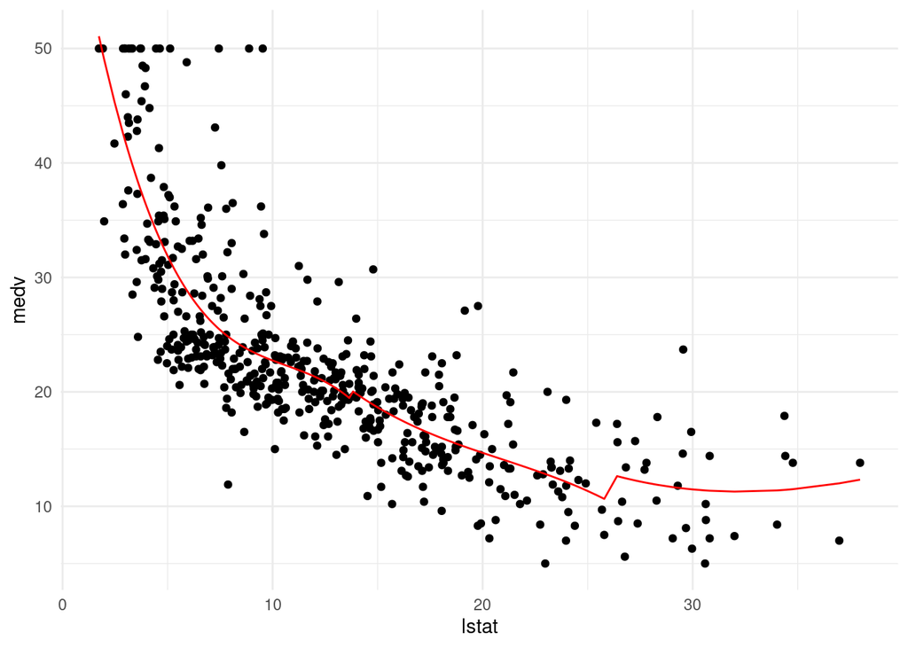

```r
pred_plot(pc2_mod)
```

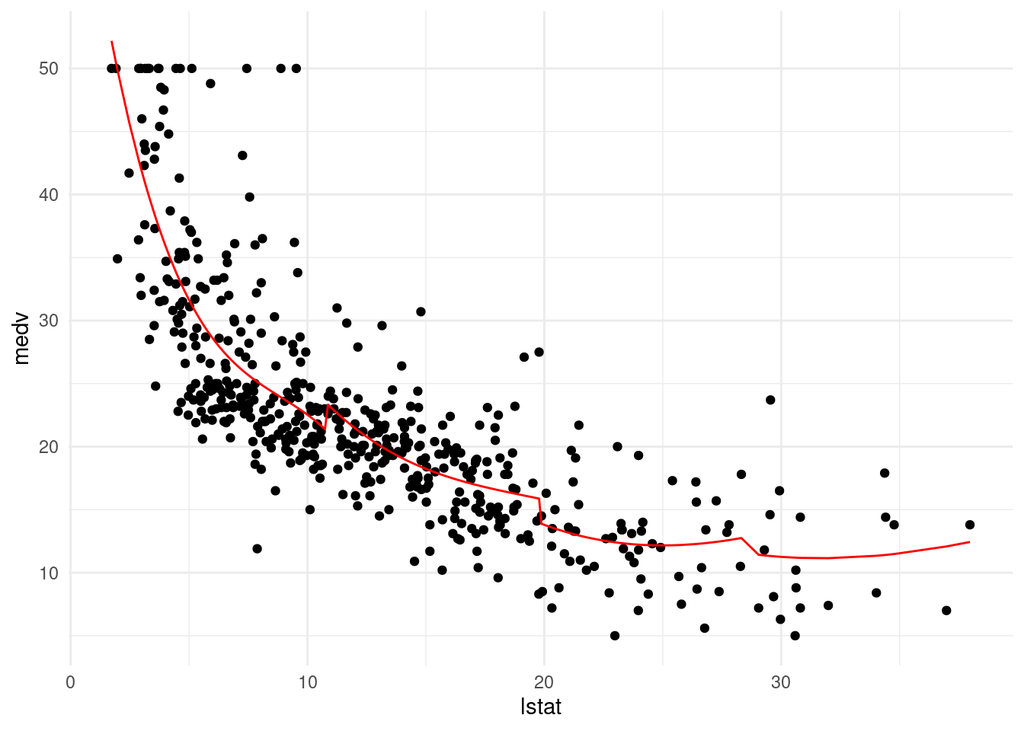

```r
pred_plot(pc3_mod)
```

11. Create a data frame called boston_tpb with the columns medv and lstat from the Boston dataset.

```r
boston_tbp = tibble(Boston[ , c("medv", "lstat")])
```

12. Now use mutate to add squared and cubed versions of the lstat variable to this dataset.

```r
boston_tpb = boston_tbp %>% mutate(lstat2 = lstat^2, lstat3 = lstat^3)
```

13. Use mutate to add a column lstat_tpb to this dataset which is 0 below the median and has value (lstat - median(lstat))^3 above the median. Tip: you may want to use ifelse() within your mutate() call.

```r
boston_tpb = boston_tpb %>%  mutate(lstat_tpb = ifelse(lstat < median(lstat),
                                                       0, (lstat -median(lstat))^3 ))
```

14. Create a linear model tpb_mod using the lm() function. How many predictors are in the model? How many degrees of freedom does this model have?

```r
tpb_mod <- lm(medv ~ ., data = boston_tpb)
summary(tpb_mod)
```

```
##
## Call:
## lm(formula = medv ~ ., data = boston_tpb)
##
## Residuals:
##      Min       1Q   Median       3Q      Max
## -13.5106  -3.0547  -0.7488   2.1178  27.1383
##
## Coefficients:
##               Estimate Std. Error t value Pr(>|t|)
## (Intercept)  65.514246   3.054303  21.450  < 2e-16 ***
## lstat       -10.324275   1.089886  -9.473  < 2e-16 ***
## lstat2        0.856576   0.116108   7.377 6.75e-13 ***
## lstat3       -0.025484   0.003810  -6.688 6.05e-11 ***
## lstat_tpb     0.026582   0.004291   6.194 1.22e-09 ***
## ---
## Signif. codes:  0 '***' 0.001 '**' 0.01 '*' 0.05 '.' 0.1 ' ' 1
##
## Residual standard error: 5.206 on 501 degrees of freedom
## Multiple R-squared:  0.6822, Adjusted R-squared:  0.6796
## F-statistic: 268.8 on 4 and 501 DF,  p-value: < 2.2e-16
```

15. Create a cubic spline model bs1_mod with a knot at the median using the bs() function. Compare its predictions to those of the tpb_mod using the predict() function on both models.

```r
bs1_mod <- lm(medv ~ bs(lstat, knots = median(lstat)), data = Boston)
summary(bs1_mod)
```

```
##
## Call:
## lm(formula = medv ~ bs(lstat, knots = median(lstat)), data = Boston)
##
## Residuals:
##      Min       1Q   Median       3Q      Max
## -13.5106  -3.0547  -0.7488   2.1178  27.1383
##
## Coefficients:
##                                   Estimate Std. Error t value Pr(>|t|)
## (Intercept)                         50.085      1.549   32.34   <2e-16 ***
## bs(lstat, knots = median(lstat))1  -24.362      2.331  -10.45   <2e-16 ***
## bs(lstat, knots = median(lstat))2  -31.781      1.927  -16.49   <2e-16 ***
## bs(lstat, knots = median(lstat))3  -44.421      3.488  -12.73   <2e-16 ***
## bs(lstat, knots = median(lstat))4  -35.831      3.092  -11.59   <2e-16 ***
## ---
## Signif. codes:  0 '***' 0.001 '**' 0.01 '*' 0.05 '.' 0.1 ' ' 1
##
## Residual standard error: 5.206 on 501 degrees of freedom
## Multiple R-squared:  0.6822, Adjusted R-squared:  0.6796
## F-statistic: 268.8 on 4 and 501 DF,  p-value: < 2.2e-16
```

```r
mean(abs(predict(bs1_mod) - predict(tpb_mod)))
```

```
## [1] 7.443848e-14
```

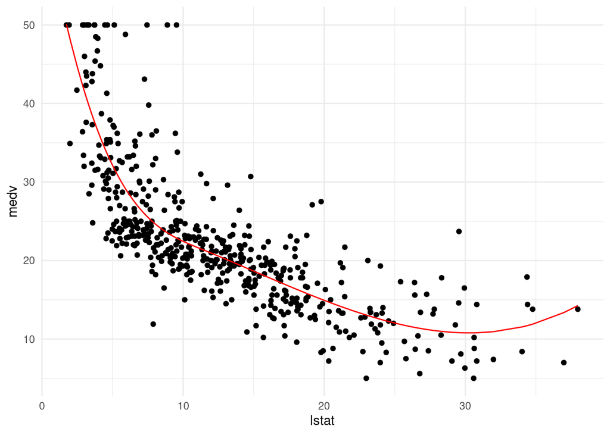

```r
pred_plot(bs1_mod)
```

Create a natural cubic spline model (ns3_mod) with 3 degrees of freedom using the ns() function. Plot it, and compare it to the bs1_mod.

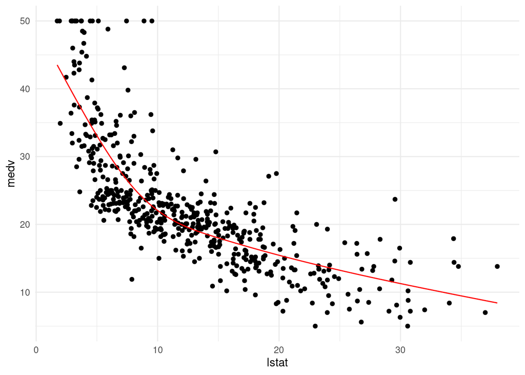

```r
ns3_mod <- lm(medv ~ ns(lstat, df = 3), data = Boston)
pred_plot(ns3_mod)
```

18. Plot lin_mod, pn3_mod, pw5_mod, pc3_mod, bs1_mod, and ns3_mod and give them nice titles by adding + ggtitle(“My title”) to the plot. You may use the function plot_grid() from the package cowplot to put your plots in a grid.

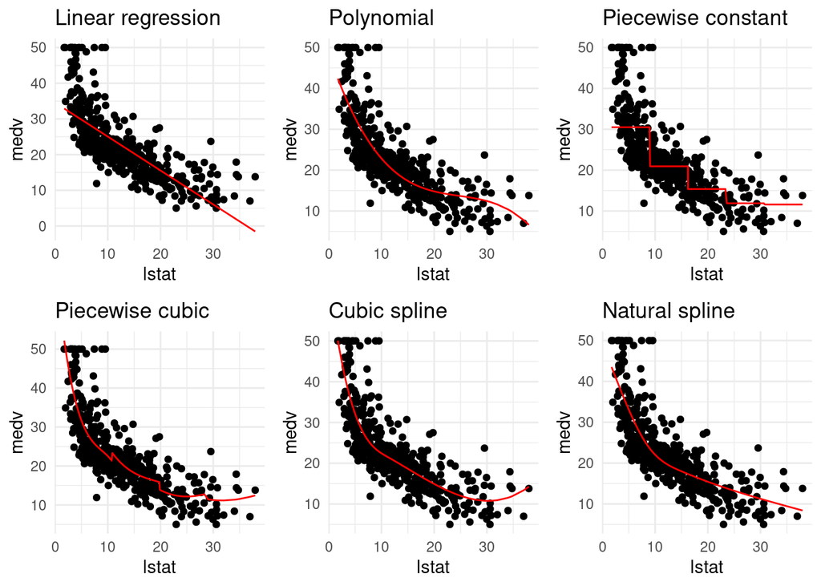

```r
library(cowplot)
plot_grid(
  pred_plot(lm_Boston) + ggtitle("Linear regression"),
  pred_plot(pn3_mod) + ggtitle("Polynomial"),
  pred_plot(pw5_mod) + ggtitle("Piecewise constant"),
  pred_plot(pc3_mod) + ggtitle("Piecewise cubic"),
  pred_plot(bs1_mod) + ggtitle("Cubic spline"),
  pred_plot(ns3_mod) + ggtitle("Natural spline")
)
```